# Stat 579 - Homework #5

9/18/2018

## Flying etiquette

FiveThirtyEight is a website founded by Statistician and writer Nate Silver to publish results from opinion poll analysis, politics, economics, and sports blogging. One of the featured articles considers [flying etiquette](https://fivethirtyeight.com/features/airplane-etiquette-recline-seat/). This article is based on data collected by FiveThirtyEight and publicly available on github. Use the code below to read in the data from the survey:

```r
fly <- read.csv("https://raw.githubusercontent.com/fivethirtyeight/data/master/flying-etiquette-survey/flying-etiquette.csv")
```

The following couple of lines of code provide a bit of cleanup of the demographic information by reaordering the levels of the corresponding factor variables. Run this code in your session.

```r
fly$Age <- factor(fly$Age, levels=c("18-29", "30-44", "45-60", "> 60", ""))
fly$Household.Income <- factor(fly$Household.Income, levels = c("$0 - $24,999","$25,000 - $49,999", "$50,000 - $99,999", "$100,000 - $149,999", "150000", ""))
fly$Education <- factor(fly$Education, levels = c("Less than high school degree", "High school degree", "Some college or Associate degree", "Bachelor degree",  "Graduate degree", ""))
```

1. Download the RMarkdown file with these homework instructions to use as a template for your work. Make sure to replace “Your Name” in the YAML with your name.
2. Some people do not travel often by plane. Provide a (visual) breakdown of travel frequency (use variable `How.often.do.you.travel.by.plane.`). Reorder the levels in the variable by travel frequency from least frequent travel to most frequent. Draw a barchart of travel frequency and comment on it. Exclude all respondents who never fly from the remainder of the analysis. How many records does the data set have now?

```r
str(fly)
```

```
## 'data.frame':    1040 obs. of  27 variables:
##  $ RespondentID                                                                                                                            : num  3.44e+09 3.43e+09 3.43e+09 3.43e+09 3.43e+09 ...
##  $ How.often.do.you.travel.by.plane.                                                                                                       : Factor w/ 6 levels "A few times per month",..: 6 6 6 6 5 6 5 6 6 6 ...
##  $ Do.you.ever.recline.your.seat.when.you.fly.                                                                                             : Factor w/ 6 levels "","About half the time",..: 1 2 6 3 2 6 5 5 5 4 ...
##  $ How.tall.are.you.                                                                                                                       : Factor w/ 21 levels "","5'0\"","5'1\"",..: 1 17 12 5 11 13 16 14 14 10 ...
##  $ Do.you.have.any.children.under.18.                                                                                                      : Factor w/ 3 levels "","No","Yes": 1 3 2 2 2 3 3 3 3 2 ...
##  $ In.a.row.of.three.seats..who.should.get.to.use.the.two.arm.rests.                                                                       : Factor w/ 6 levels "","Other (please specify)",..: 1 3 6 3 5 6 5 3 3 2 ...
##  $ In.a.row.of.two.seats..who.should.get.to.use.the.middle.arm.rest.                                                                       : Factor w/ 6 levels "","Other (please specify)",..: 1 3 3 3 5 6 6 3 3 2 ...
##  $ Who.should.have.control.over.the.window.shade.                                                                                          : Factor w/ 3 levels "","Everyone in the row should have some say",..: 1 2 3 2 2 3 2 3 3 2 ...
##  $ Is.itrude.to.move.to.an.unsold.seat.on.a.plane.                                                                                         : Factor w/ 4 levels "","No, not rude at all",..: 1 2 2 2 2 3 2 2 2 4 ...
##  $ Generally.speaking..is.it.rude.to.say.more.than.a.few.words.tothe.stranger.sitting.next.to.you.on.a.plane.                              : Factor w/ 4 levels "","No, not at all rude",..: 1 2 2 2 2 2 3 2 2 4 ...
##  $ On.a.6.hour.flight.from.NYC.to.LA..how.many.times.is.it.acceptable.to.get.up.if.you.re.not.in.an.aisle.seat.                            : Factor w/ 7 levels "","Four times",..: 1 7 6 6 7 5 7 2 2 3 ...
##  $ Under.normal.circumstances..does.a.person.who.reclines.their.seat.during.a.flight.have.any.obligation.to.the.person.sitting.behind.them.: Factor w/ 3 levels "","No, the person on the flight has no obligation to the person behind them",..: 1 3 3 2 2 3 2 3 3 3 ...
##  $ Is.itrude.to.recline.your.seat.on.a.plane.                                                                                              : Factor w/ 4 levels "","No, not rude at all",..: 1 3 2 2 2 2 3 2 2 4 ...
##  $ Given.the.opportunity..would.you.eliminate.the.possibility.of.reclining.seats.on.planes.entirely.                                       : Factor w/ 3 levels "","No","Yes": 1 2 2 2 2 2 3 3 3 3 ...
##  $ Is.it.rude.to.ask.someone.to.switch.seats.with.you.in.order.to.be.closer.to.friends.                                                    : Factor w/ 4 levels "","No, not at all rude",..: 1 2 2 3 2 3 3 2 1 4 ...
##  $ Is.itrude.to.ask.someone.to.switch.seats.with.you.in.order.to.be.closer.to.family.                                                      : Factor w/ 4 levels "","No, not at all rude",..: 1 2 2 2 2 2 2 2 1 4 ...
##  $ Is.it.rude.to.wake.a.passenger.up.if.you.are.trying.to.go.to.the.bathroom.                                                              : Factor w/ 4 levels "","No, not at all rude",..: 1 2 2 2 3 3 2 2 1 4 ...
##  $ Is.itrude.to.wake.a.passenger.up.if.you.are.trying.to.walk.around.                                                                      : Factor w/ 4 levels "","No, not at all rude",..: 1 2 3 3 3 4 2 3 1 4 ...
##  $ In.general..is.itrude.to.bring.a.baby.on.a.plane.                                                                                       : Factor w/ 4 levels "","No, not at all rude",..: 1 2 3 3 3 4 2 3 1 4 ...
##  $ In.general..is.it.rude.to.knowingly.bring.unruly.children.on.a.plane.                                                                   : Factor w/ 4 levels "","No, not at all rude",..: 1 2 4 4 4 4 3 4 1 4 ...
##  $ Have.you.ever.used.personal.electronics.during.take.off.or.landing.in.violation.of.a.flight.attendant.s.direction.                      : Factor w/ 3 levels "","No","Yes": 1 2 2 2 3 2 2 2 1 2 ...
##  $ Have.you.ever.smoked.a.cigarette.in.an.airplane.bathroom.when.it.was.against.the.rules.                                                 : Factor w/ 3 levels "","No","Yes": 1 2 2 2 2 2 2 2 1 2 ...
##  $ Gender                                                                                                                                  : Factor w/ 3 levels "","Female","Male": 1 3 3 3 3 3 3 3 1 3 ...
##  $ Age                                                                                                                                     : Factor w/ 5 levels "18-29","30-44",..: 5 2 2 2 2 2 2 2 5 2 ...
##  $ Household.Income                                                                                                                        : Factor w/ 6 levels "$0 - $24,999",..: 6 6 4 1 3 2 5 1 6 1 ...
##  $ Education                                                                                                                               : Factor w/ 6 levels "Less than high school degree",..: 6 5 4 4 4 5 3 4 6 4 ...
##  $ Location..Census.Region.                                                                                                                : Factor w/ 10 levels "","East North Central",..: 1 7 7 7 7 2 7 6 1 7 ...
```

```r
fly$travel_freq <- fly$How.often.do.you.travel.by.plane.
levels(fly$travel_freq)
```

```
## [1] "A few times per month" "A few times per week"  "Every day"
## [4] "Never"                 "Once a month or less"  "Once a year or less"
```

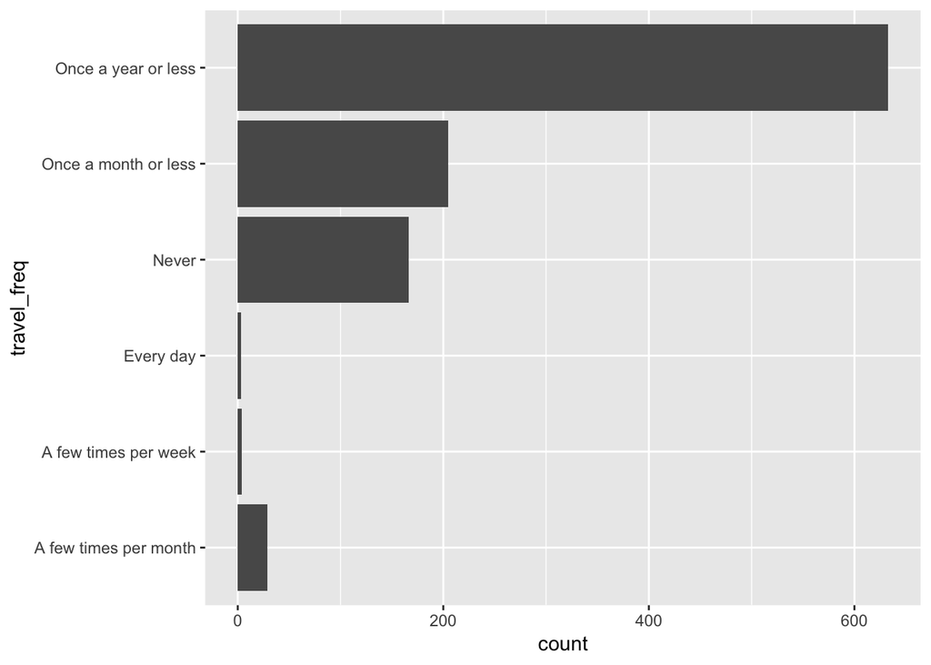

```r
library(ggplot2)
ggplot(data = fly, aes(x = travel_freq)) + geom_bar() + coord_flip()
```

```r
freq_order <- c("Never", "Once a year or less", "Once a month or less", "A few times per month", "A few times per week", "Every day")

fly$travel_freq <- factor(fly$travel_freq, levels = freq_order)
levels(fly$travel_freq)
```

```
## [1] "Never"                 "Once a year or less"   "Once a month or less"
## [4] "A few times per month" "A few times per week"  "Every day"
```

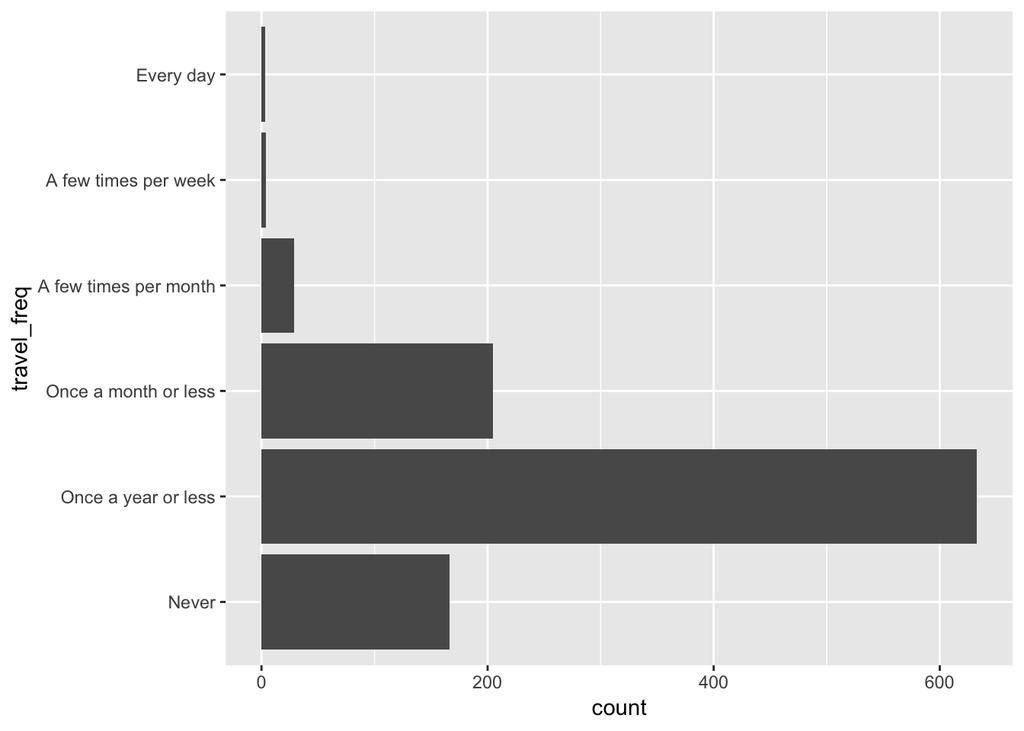

```r
ggplot(data = fly, aes(x = travel_freq)) + geom_bar() + coord_flip()
```

```r
library(tidyr)
fly<-fly[fly$How.often.do.you.travel.by.plane.!="Never", ]
str(fly)
```

```
## 'data.frame':    874 obs. of  28 variables:
##  $ RespondentID                                                                                                                            : num  3.44e+09 3.43e+09 3.43e+09 3.43e+09 3.43e+09 ...
##  $ How.often.do.you.travel.by.plane.                                                                                                       : Factor w/ 6 levels "A few times per month",..: 6 6 6 6 5 6 5 6 6 6 ...
##  $ Do.you.ever.recline.your.seat.when.you.fly.                                                                                             : Factor w/ 6 levels "","About half the time",..: 1 2 6 3 2 6 5 5 5 4 ...
##  $ How.tall.are.you.                                                                                                                       : Factor w/ 21 levels "","5'0\"","5'1\"",..: 1 17 12 5 11 13 16 14 14 10 ...
##  $ Do.you.have.any.children.under.18.                                                                                                      : Factor w/ 3 levels "","No","Yes": 1 3 2 2 2 3 3 3 3 2 ...
##  $ In.a.row.of.three.seats..who.should.get.to.use.the.two.arm.rests.                                                                       : Factor w/ 6 levels "","Other (please specify)",..: 1 3 6 3 5 6 5 3 3 2 ...
##  $ In.a.row.of.two.seats..who.should.get.to.use.the.middle.arm.rest.                                                                       : Factor w/ 6 levels "","Other (please specify)",..: 1 3 3 3 5 6 6 3 3 2 ...
##  $ Who.should.have.control.over.the.window.shade.                                                                                          : Factor w/ 3 levels "","Everyone in the row should have some say",..: 1 2 3 2 2 3 2 3 3 2 ...
##  $ Is.itrude.to.move.to.an.unsold.seat.on.a.plane.                                                                                         : Factor w/ 4 levels "","No, not rude at all",..: 1 2 2 2 2 3 2 2 2 4 ...
##  $ Generally.speaking..is.it.rude.to.say.more.than.a.few.words.tothe.stranger.sitting.next.to.you.on.a.plane.                              : Factor w/ 4 levels "","No, not at all rude",..: 1 2 2 2 2 2 3 2 2 4 ...
##  $ On.a.6.hour.flight.from.NYC.to.LA..how.many.times.is.it.acceptable.to.get.up.if.you.re.not.in.an.aisle.seat.                            : Factor w/ 7 levels "","Four times",..: 1 7 6 6 7 5 7 2 2 3 ...
##  $ Under.normal.circumstances..does.a.person.who.reclines.their.seat.during.a.flight.have.any.obligation.to.the.person.sitting.behind.them.: Factor w/ 3 levels "","No, the person on the flight has no obligation to the person behind them",..: 1 3 3 2 2 3 2 3 3 3 ...
##  $ Is.itrude.to.recline.your.seat.on.a.plane.                                                                                              : Factor w/ 4 levels "","No, not rude at all",..: 1 3 2 2 2 2 3 2 2 4 ...
##  $ Given.the.opportunity..would.you.eliminate.the.possibility.of.reclining.seats.on.planes.entirely.                                       : Factor w/ 3 levels "","No","Yes": 1 2 2 2 2 2 3 3 3 3 ...
##  $ Is.it.rude.to.ask.someone.to.switch.seats.with.you.in.order.to.be.closer.to.friends.                                                    : Factor w/ 4 levels "","No, not at all rude",..: 1 2 2 3 2 3 3 2 1 4 ...
##  $ Is.itrude.to.ask.someone.to.switch.seats.with.you.in.order.to.be.closer.to.family.                                                      : Factor w/ 4 levels "","No, not at all rude",..: 1 2 2 2 2 2 2 2 1 4 ...
##  $ Is.it.rude.to.wake.a.passenger.up.if.you.are.trying.to.go.to.the.bathroom.                                                              : Factor w/ 4 levels "","No, not at all rude",..: 1 2 2 2 3 3 2 2 1 4 ...
##  $ Is.itrude.to.wake.a.passenger.up.if.you.are.trying.to.walk.around.                                                                      : Factor w/ 4 levels "","No, not at all rude",..: 1 2 3 3 3 4 2 3 1 4 ...
```

[output cut: 10 more lines]

The data set has 874 values if we exclude people that never travel at all.

3. In the demographic variables (`Education`, `Age`, and `Houshold.Income`), replace all occurrences of the empty string "" by a missing value `NA`. How many responses in each variable do not have any missing values? How many responses have no missing values in any of the three variables? (Hint: think of the function `is.na`)

```r
is.na(fly$Education) <- fly$Education == ''
is.na(fly$Age) <- fly$Age == ''
is.na(fly$Household.Income) <-fly$Household.Income == ''

length(which(!is.na(fly$Education)))
```

```
## [1] 837
```

```r
length(which(!is.na(fly$Age)))
```

```
## [1] 843
```

```r
length(which(!is.na(fly$Household.Income)))
```

```
## [1] 698
```

```r
library(dplyr)
fly2<-fly %>% select(Education, Age, Household.Income)
fly3<-fly2%>%na.omit(Education, Age, Household.Income )
nrow(fly3)
```

```
## [1] 696
```

Education has 837 responses, Age has 843 responses and Household.Income has 698 responses. Responses without missing values in any of the three variables are 696.

4. Run the command below and interpret the output. What potential purpose can you see for the chart? What might be a problem with the chart? Find at least one purpose and one problem.

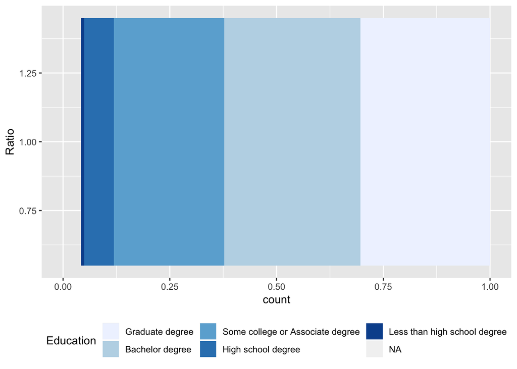

```r
library(ggplot2)
fly$Education = with(fly, factor(Education, levels = rev(levels(Education))))

ggplot(data = fly, aes(x = 1)) +
  geom_bar(aes(fill=Education), position="fill") +
  coord_flip() +
  theme(legend.position="bottom") +
  scale_fill_brewer() +
  xlab("Ratio")
```

The graph shows the proportion of different levels of education of the people surveyed. In general, people of different levels of education are well represented in the study set, except for people with only high school degree or less than high school degree. This type of graph could be useful to visualize proportion of different levels within a factor variable. However, it is confusing regarding the x axis (Ratio) which seems to not contribute to the analysis of the graph.

5. Rename the variable `In.general..is.itrude.to.bring.a.baby.on.a.plane.` to `baby.on.plane.`. How many levels does the variable `baby.on.plane` have, and what are these levels? Rename the level labeled "" to “Not answered”. Bring the levels of `baby.on.plane` in an order from least rude to most rude. Put the level “Not answered” last. Draw a barchart of variable `baby.on.plane`. Interpret the result. (This question is very similar to question 2, but preps the data for the next question)

```r
fly$baby.on.plane <- fly$In.general..is.itrude.to.bring.a.baby.on.a.plane.
levels(fly$baby.on.plane)
```

```
## [1] ""                    "No, not at all rude" "Yes, somewhat rude"
## [4] "Yes, very rude"
```

```r
levels(fly$baby.on.plane)[1] <- "Not answered"
levels(fly$baby.on.plane)
```

```
## [1] "Not answered"        "No, not at all rude" "Yes, somewhat rude"
## [4] "Yes, very rude"
```

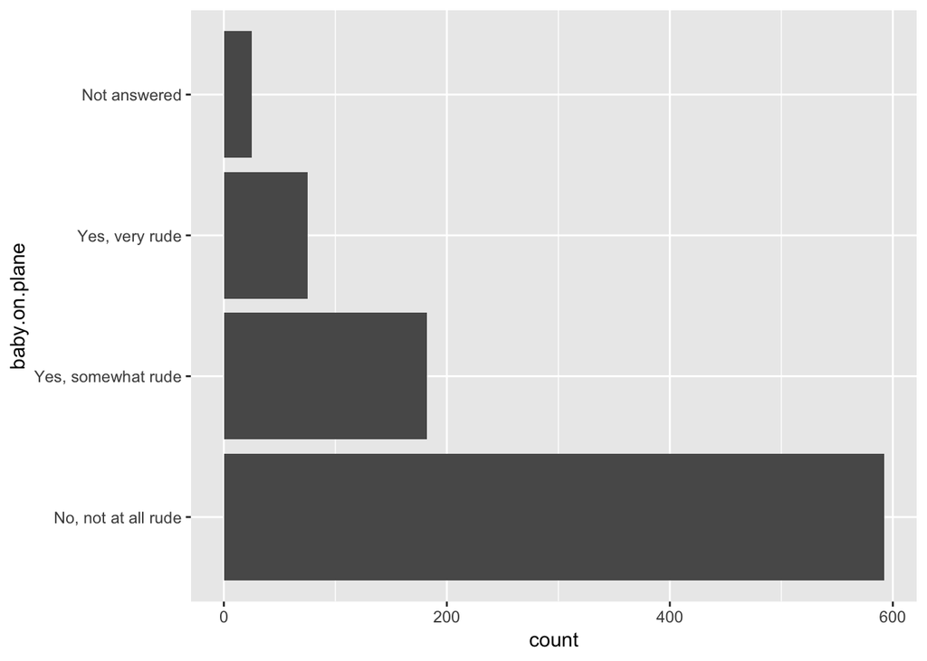

```r
baby_rude_levels <- levels(fly$baby.on.plane)[c(2, 3, 4, 1)]


fly$baby.on.plane <- factor(fly$baby.on.plane, levels = baby_rude_levels)
ggplot(data = fly, aes(x = baby.on.plane)) + geom_bar() + coord_flip()
```

The variable baby.on.plane has 4 levels: "“,”No, not at all rude“,”Yes, somewhat rude“,”Yes, very rude".

From the total amount of people surveyed, almost 600 answered that is not rude at all to bring a baby on a plane. Also, 175 people think that it is somewhat rude and around 75 thinks that it is actually very rude to bring a baby on a plane. Finally, there are approximately 25 people that did not answered the question.

6. Investigate the relationship between gender and the variables `Do.you.have.any.children.under.18.` and `baby.on.plane`. How is the attitude towards babies on planes shaped by gender and own children under 18? Find a plot that summarises your findings (use `ggplot2`).

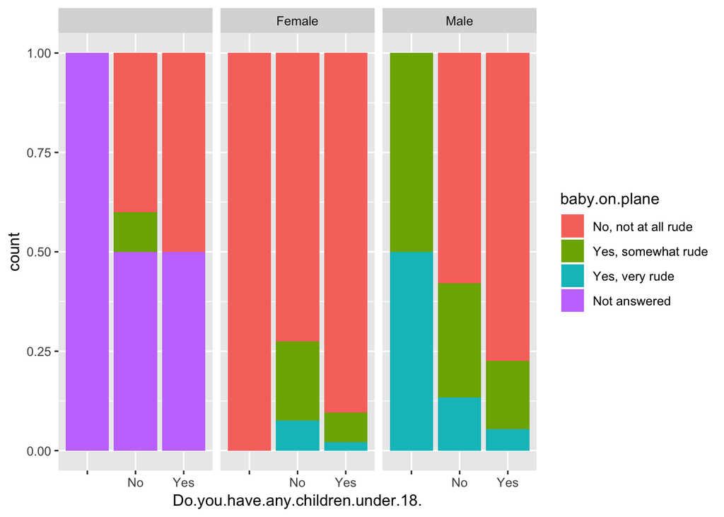

```r
fly5<-fly %>% select(baby.on.plane, Do.you.have.any.children.under.18., Gender)
ggplot(data = fly5, aes(x = Do.you.have.any.children.under.18., fill=baby.on.plane)) + geom_bar(position="Fill") + facet_wrap(~Gender)
```

The attitude towards babies on planes could be ordered from high accetance to low acceptance as:

1. Females with a child under 18
2. Males with a child under 18
3. Females without a child under 18
4. Males without a child under 18

Therefore, having a child under 18 helps to tolerate babies on a plane for both genders. Females seems to tolerate more than males if both genders have cihldrens under 18 and if both genders do not have a children under 18.

Due date: the homework is due a week from now on Thursday.

For the submission: submit your solution in an R Markdown file and (just for insurance) submit the corresponding html/word file with it.